# Statistical Evaluation : Sample Size and Power Calculations for Tests Comparing Means in Clinical Research

John Pauline Pineda

May 7, 2023

# **1. Table of Contents**

This project explores different sample size and power calculations for mean comparison tests in clinical research using various helpful packages in **R**. The important factors to be assessed prior to determining the appropriate sample sizes were evaluated for the **One-Sample**, **Two-Sample** and **Multiple-Sample One-Way ANOVA Pairwise** designs. Power analyses were conducted to address the requirements across different study hypotheses including Tests of Equality, Non-Inferiority, Superiority and Equivalence. All results were consolidated in a **Summary** presented at the end of the document.  
Mean comparison tests applied during clinical research refer to trials evaluated in terms of mean responses of certain primary study endpoints. The objectives of the intended clinical trials usually include the evaluation of intervention effects, demonstration of therapeutic equivalence or non-inferiority and establishment of superiority. The equations applied in this study (mostly contained from the book **Sample Size Calculations in Clinical Research** and implemented using the **base** package) attempt to provide calculations for the sample size and statistical power based on the study objectives and hypotheses of interest.

## 1.1 One-Sample Design (OSD)

[One-Sample Design](https://www.taylorfrancis.com/books/mono/10.1201/9781315183084/sample-size-calculations-clinical-research-shein-chung-chow-jun-shao-hansheng-wang-yuliya-lokhnygina) involves individual numeric response values from sampled subjects. In clinical research, responses could be the difference between matched pairs such as the pre-treatment and post-treatment responses or changes from baseline to endpoint within a treatment group. Responses are assumed to be independent and identically distributed normal random variables with zero mean and a given variance. Parameters needed for the computations are as follows:  
**[A]** Mean Response : True mean response value obtained from sampled subjects  
**[B]** Reference : Baseline value for comparison  
**[C]** Standard Deviation : Data variability based from literature, pilot studies or preliminary experiments  
**[D]** Alpha : Maximum allowed Type I error  
**[E]** Beta : Maximum allowed Type II error  
**[F]** Delta :  
**[F.1]** Minimum testing margin to establish that the mean response is much better than reference  
**[F.2]** Minimum testing margin to establish that the mean response is not much worse as the reference  
**[F.3]** Minimum testing margin to establish that the mean response is no better and no worse than the reference  
A case scenario was provided as follows to demonstrate sample size computation and power analysis as applied on different types of hypotheses:  
**[Case Scenario]** A clinical research study is being pursued concerning osteoporosis in post-menopausal women. Osteoporosis and osteopenia (or decreased bone mass) most commonly develop in post-menopausal women. The consequences of osteoporosis are vertebral crush fractures and hip fractures. The diagnosis of osteoporosis is made when vertebral bone density is more than 10% below what is expected for sex, age, height, weight, and race. Usually, bone density is reported in terms of standard deviation (SD) from mean values. The World Health Organization (WHO) defines osteopenia as bone density value greater than one SD below peak bone mass levels in young women and osteoporosis as a value of greater than 2.5 SD below the same measurement scale. In medical practice, most clinicians suggest therapeutic intervention should be begun in patients with osteopenia to prevent progression to osteoporosis.

### 1.1.1 Test for Equality (OSD_EQUALITY)

**[Research Question]** Suppose that the mean bone density before the treatment is 1.5 SD. After treatment, the mean value is expected to range from 2.0 to 4.0 SD with increments of 0.2. For prevention of progression from osteopenia to osteoporosis, the study aims to demonstrate that the mean bone density post-treatment and pre-treatment are different. Given a level of significance of 0.05, evaluate the sample size range for a test of equality to achieve statistical test powers equal to 70%, 80% and 90%.  
**[Null Hypothesis]** Post-treatment mean bone density - Pre-treatment mean bone density equals 0  
**[Alternative Hypothesis]** Post-treatment mean bone density - Pre-treatment mean bone density does not equal 0  
**[Hypothesis Test]** Rejection of the null hypothesis implies difference between the mean bone density values post-treatment and pre-treatment  
**[A]** Mean Response : 2.0 to 4.0 SD at 0.20 intervals  
**[B]** Reference : 1.5 SD  
**[C]** Standard Deviation : Not explicitly given but already factored into the mean values and will cancel out during computation  
**[D]** Alpha : 0.05  
**[E]** Beta : 0.30, 0.20 and 0.10 corresponding to 70%, 80% and 90% statistical powers  
**[F]** Delta : 0 testing margin for the Test of Equality hypothesis

**Code Chunk | Output**

```r
##################################
# Loading R libraries
##################################
library(moments)
library(car)
library(multcomp)
library(effects)
library(psych)
library(ggplot2)
library(dplyr)
library(ggpubr)
library(rstatix)
library(ggfortify)
library(trend)

##################################
# Defining a range of possible hypothesized values for mu_Response
##################################
mu_Response=seq(2.0,4.0,0.2)

##################################
# Defining a fixed hypothesized value for mu_Reference
##################################
mu_Reference=1.5

##################################
# Defining a fixed hypothesized value for the standard deviation
##################################
sd=1

##################################
# Defining a fixed hypothesized value for the Type I error
##################################
alpha=0.05

##################################
# Defining a range of possible hypothesized values for the Type II error
##################################
beta=c(0.30,0.20,0.10)

##################################
# Computing the range of samples sizes based on different levels of Type II errors
##################################
beta_1=beta[1]
(n_Beta30=(sd*(qnorm(1-alpha/2)+qnorm(1-beta_1))/(mu_Response-mu_Reference))^2)
```

```
##  [1] 24.6882678 12.5960550  7.6198357  5.1008818  3.6521106  2.7431409
##  [7]  2.1356633  1.7097138  1.3995617  1.1667423  0.9875307
```

```r
ceiling(n_Beta30)
```

```
##  [1] 25 13  8  6  4  3  3  2  2  2  1
```

```r
z_Beta30=(mu_Response-mu_Reference)/(sd/sqrt(n_Beta30))
(Power_Beta30=pnorm(z_Beta30-qnorm(1-alpha/2))+pnorm(-z_Beta30-qnorm(1-alpha/2)))
```

```
##  [1] 0.7000044 0.7000044 0.7000044 0.7000044 0.7000044 0.7000044 0.7000044
##  [8] 0.7000044 0.7000044 0.7000044 0.7000044
```

```r
beta_2=beta[2]
(n_Beta20=(sd*(qnorm(1-alpha/2)+qnorm(1-beta_2))/(mu_Response-mu_Reference))^2)
```

```
##  [1] 31.395519 16.018122  9.689975  6.486677  4.644308  3.488391  2.715875
##  [8]  2.174205  1.779791  1.483720  1.255821
```

```r
ceiling(n_Beta20)
```

```
##  [1] 32 17 10  7  5  4  3  3  2  2  2
```

```r
z_Beta20=(mu_Response-mu_Reference)/(sd/sqrt(n_Beta20))
(Power_Beta20=pnorm(z_Beta20-qnorm(1-alpha/2))+pnorm(-z_Beta20-qnorm(1-alpha/2)))
```

```
##  [1] 0.800001 0.800001 0.800001 0.800001 0.800001 0.800001 0.800001 0.800001
##  [9] 0.800001 0.800001 0.800001
```

```r
beta_3=beta[3]
(n_Beta10=(sd*(qnorm(1-alpha/2)+qnorm(1-beta_3))/(mu_Response-mu_Reference))^2)
```

```
##  [1] 42.029692 21.443721 12.972127  8.683821  6.217410  4.669966  3.635787
##  [8]  2.910644  2.382636  1.986280  1.681188
```

```r
ceiling(n_Beta10)
```

```
##  [1] 43 22 13  9  7  5  4  3  3  2  2
```

```r
z_Beta10=(mu_Response-mu_Reference)/(sd/sqrt(n_Beta10))
(Power_Beta10=pnorm(z_Beta10-qnorm(1-alpha/2))+pnorm(-z_Beta10-qnorm(1-alpha/2)))
```

```
##  [1] 0.9000001 0.9000001 0.9000001 0.9000001 0.9000001 0.9000001 0.9000001
##  [8] 0.9000001 0.9000001 0.9000001 0.9000001
```

```r
OneSampleDesign.Equality <- as.data.frame(cbind(mu_Response,n_Beta30,n_Beta20,n_Beta10))
names(OneSampleDesign.Equality) <- c("Posttreatment.Mean.Bone.Density",
                                 "Power=70%",
                                 "Power=80%",
                                 "Power=90%")

##################################
# Restructuring the data
##################################
OneSampleDesign.Equality.Reshaped <- gather(OneSampleDesign.Equality,
                                            "Power=70%","Power=80%","Power=90%",
                                            key="Power",
                                            value="Sample.Size")
OneSampleDesign.Equality.Reshaped$Label <- rep("OSD_EQUALITY",nrow(OneSampleDesign.Equality.Reshaped))

OneSampleDesign.Equality.Reshaped
```

```
##    Posttreatment.Mean.Bone.Density     Power Sample.Size        Label
## 1                              2.0 Power=70%  24.6882678 OSD_EQUALITY
## 2                              2.2 Power=70%  12.5960550 OSD_EQUALITY
## 3                              2.4 Power=70%   7.6198357 OSD_EQUALITY
## 4                              2.6 Power=70%   5.1008818 OSD_EQUALITY
## 5                              2.8 Power=70%   3.6521106 OSD_EQUALITY
## 6                              3.0 Power=70%   2.7431409 OSD_EQUALITY
## 7                              3.2 Power=70%   2.1356633 OSD_EQUALITY
## 8                              3.4 Power=70%   1.7097138 OSD_EQUALITY
## 9                              3.6 Power=70%   1.3995617 OSD_EQUALITY
## 10                             3.8 Power=70%   1.1667423 OSD_EQUALITY
## 11                             4.0 Power=70%   0.9875307 OSD_EQUALITY
## 12                             2.0 Power=80%  31.3955189 OSD_EQUALITY
## 13                             2.2 Power=80%  16.0181219 OSD_EQUALITY
## 14                             2.4 Power=80%   9.6899750 OSD_EQUALITY
```

[output cut: 19 more lines]

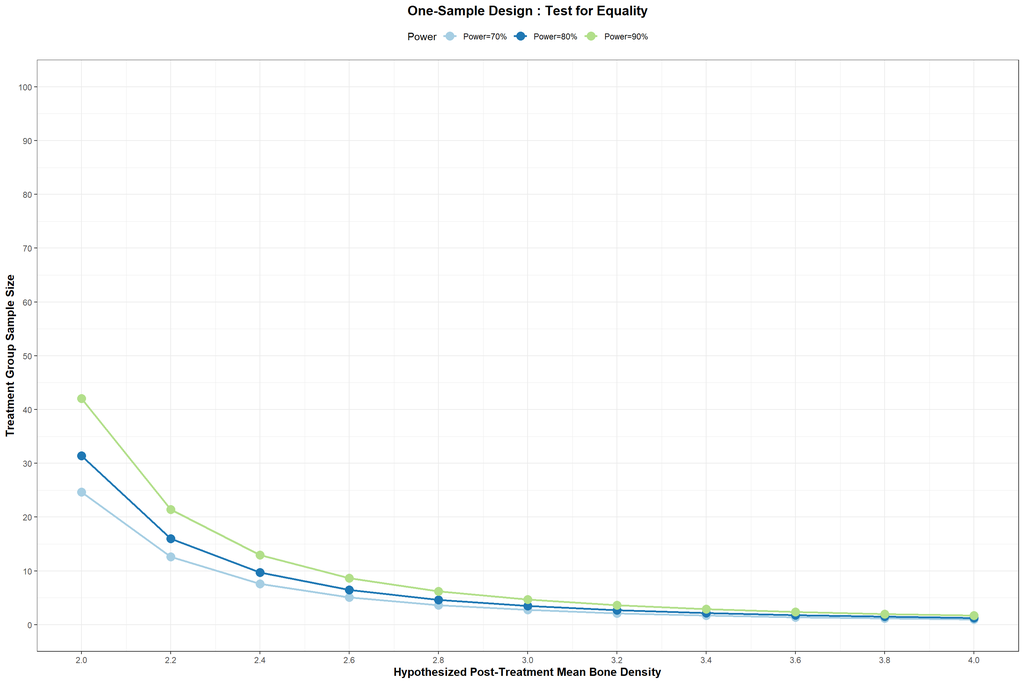

```r
##################################
# Plotting the sample sizes and power curves
##################################
(OneSampleDesign.Equality.PowerAnalysis <- ggplot(OneSampleDesign.Equality.Reshaped,
                                                      aes(x=Posttreatment.Mean.Bone.Density,
                                                          y=Sample.Size,
                                                          color=Power)) +
   geom_line(size=1)+
   geom_point(size=4)+
   theme_bw() +
   scale_color_brewer(palette="Paired") +
   scale_x_continuous(name="Hypothesized Post-Treatment Mean Bone Density",
                      limits=c(2,4),
                      breaks=seq(2,4,
                                 by=0.2)) +
  scale_y_continuous(name="Treatment Group Sample Size",
                     limits=c(0,100),
                     breaks=seq(0,100,by=10)) +
  theme(axis.title.x=element_text(color="black",face="bold",size=12),
        legend.position="top",
        axis.title.y=element_text(color="black",face="bold",size=12),
        plot.title=element_text(color="black",size=14,face="bold",hjust=0.50)) +
  ggtitle("One-Sample Design : Test for Equality"))
```

### 1.1.2 Test for Non-Inferiority (OSD_NONINFERIORITY)

**[Research Question]** Suppose that the mean bone density before the treatment is 1.5 SD. After treatment, the mean value is expected to range from 2.0 to 4.0 SD with increments of 0.2. For prevention of progression from osteopenia to osteoporosis, the study aims to demonstrate that the mean bone density post-treatment is not much worse than pre-treatment by a clinically meaningful difference equal to −0.5 SD. Given a level of significance of 0.05, evaluate the sample size range for a test of non-inferiority to achieve statistical test powers equal to 70%, 80% and 90%.  
**[Null Hypothesis]** Post-treatment mean bone density - Pre-treatment mean bone density <= Clinically meaningful difference  
**[Alternative Hypothesis]** Post-treatment mean bone density - Pre-treatment mean bone density > Clinically meaningful difference  
**[Hypothesis Test]** Rejection of the null hypothesis implies non-inferiority of the mean bone density treatment as compared to non-treatment, given the delta  
**[A]** Mean Response : 2.0 to 4.0 SD at 0.20 intervals  
**[B]** Reference : 1.5 SD  
**[C]** Standard Deviation : Not explicitly given but already factored into the mean values and will cancel out during computation  
**[D]** Alpha : 0.05  
**[E]** Beta : 0.30, 0.20 and 0.10 corresponding to 70%, 80% and 90% statistical powers  
**[F]** Delta : -0.50 SD testing margin for the Test of Non-Inferiority hypothesis

**Code Chunk | Output**

```r
##################################
# Defining a range of possible hypothesized values for mu_Response
##################################
mu_Response=seq(2.0,4.0,0.2)

##################################
# Defining a fixed hypothesized value for mu_Reference
##################################
mu_Reference=1.5

##################################
# Defining a fixed hypothesized value for the standard deviation
##################################
sd=1

##################################
# Defining a fixed hypothesized value for the Type I error
##################################
alpha=0.05

##################################
# Defining a range of possible hypothesized values for the Type II error
##################################
beta=c(0.30,0.20,0.10)

##################################
# Defining the non-inferiority delta
##################################
delta=-0.50

##################################
# Computing the range of samples sizes based on different levels of Type II errors
##################################
beta_1=beta[1]
(n_Beta30=(sd*(qnorm(1-alpha)+qnorm(1-beta_1))/(mu_Response-mu_Reference-delta))^2)
```

```
##  [1] 4.7056635 3.2678219 2.4008487 1.8381498 1.4523653 1.1764159 0.9722445
##  [8] 0.8169555 0.6961041 0.6002122 0.5228515
```

```r
ceiling(n_Beta30)
```

```
##  [1] 5 4 3 2 2 2 1 1 1 1 1
```

```r
z_Beta30=(mu_Response-mu_Reference-delta)/(sd/sqrt(n_Beta30))
(Power_Beta30=pnorm(z_Beta30-qnorm(1-alpha))+pnorm(-z_Beta30-qnorm(1-alpha)))
```

```
##  [1] 0.7000683 0.7000683 0.7000683 0.7000683 0.7000683 0.7000683 0.7000683
##  [8] 0.7000683 0.7000683 0.7000683 0.7000683
```

```r
beta_2=beta[2]
(n_Beta20=(sd*(qnorm(1-alpha)+qnorm(1-beta_2))/(mu_Response-mu_Reference-delta))^2)
```

```
##  [1] 6.1825572 4.2934425 3.1543659 2.4150614 1.9081967 1.5456393 1.2773879
##  [8] 1.0733606 0.9145795 0.7885915 0.6869508
```

```r
ceiling(n_Beta20)
```

```
##  [1] 7 5 4 3 2 2 2 2 1 1 1
```

```r
z_Beta20=(mu_Response-mu_Reference-delta)/(sd/sqrt(n_Beta20))
(Power_Beta20=pnorm(z_Beta20-qnorm(1-alpha))+pnorm(-z_Beta20-qnorm(1-alpha)))
```

```
##  [1] 0.800018 0.800018 0.800018 0.800018 0.800018 0.800018 0.800018 0.800018
##  [9] 0.800018 0.800018 0.800018
```

```r
beta_3=beta[3]
(n_Beta10=(sd*(qnorm(1-alpha)+qnorm(1-beta_3))/(mu_Response-mu_Reference-delta))^2)
```

```
##  [1] 8.5638474 5.9471162 4.3693099 3.3452529 2.6431628 2.1409618 1.7693899
##  [8] 1.4867791 1.2668413 1.0923275 0.9515386
```

```r
ceiling(n_Beta10)
```

```
##  [1] 9 6 5 4 3 3 2 2 2 2 1
```

```r
z_Beta10=(mu_Response-mu_Reference-delta)/(sd/sqrt(n_Beta10))
(Power_Beta10=pnorm(z_Beta10-qnorm(1-alpha))+pnorm(-z_Beta10-qnorm(1-alpha)))
```

```
##  [1] 0.9000024 0.9000024 0.9000024 0.9000024 0.9000024 0.9000024 0.9000024
##  [8] 0.9000024 0.9000024 0.9000024 0.9000024
```

```r
OneSampleDesign.NonInferiority <- as.data.frame(cbind(mu_Response,n_Beta30,n_Beta20,n_Beta10))
names(OneSampleDesign.NonInferiority) <- c("Posttreatment.Mean.Bone.Density",
                                 "Power=70%",
                                 "Power=80%",
                                 "Power=90%")

##################################
# Restructuring the data
##################################
OneSampleDesign.NonInferiority.Reshaped <- gather(OneSampleDesign.NonInferiority,
                                            "Power=70%","Power=80%","Power=90%",
                                            key="Power",
                                            value="Sample.Size")
OneSampleDesign.NonInferiority.Reshaped$Label <- rep("OSD_NONINFERIORITY",nrow(OneSampleDesign.NonInferiority.Reshaped))

OneSampleDesign.NonInferiority.Reshaped
```

```
##    Posttreatment.Mean.Bone.Density     Power Sample.Size              Label
## 1                              2.0 Power=70%   4.7056635 OSD_NONINFERIORITY
## 2                              2.2 Power=70%   3.2678219 OSD_NONINFERIORITY
## 3                              2.4 Power=70%   2.4008487 OSD_NONINFERIORITY
## 4                              2.6 Power=70%   1.8381498 OSD_NONINFERIORITY
## 5                              2.8 Power=70%   1.4523653 OSD_NONINFERIORITY
## 6                              3.0 Power=70%   1.1764159 OSD_NONINFERIORITY
## 7                              3.2 Power=70%   0.9722445 OSD_NONINFERIORITY
## 8                              3.4 Power=70%   0.8169555 OSD_NONINFERIORITY
## 9                              3.6 Power=70%   0.6961041 OSD_NONINFERIORITY
## 10                             3.8 Power=70%   0.6002122 OSD_NONINFERIORITY
## 11                             4.0 Power=70%   0.5228515 OSD_NONINFERIORITY
## 12                             2.0 Power=80%   6.1825572 OSD_NONINFERIORITY
## 13                             2.2 Power=80%   4.2934425 OSD_NONINFERIORITY
## 14                             2.4 Power=80%   3.1543659 OSD_NONINFERIORITY
```

[output cut: 19 more lines]

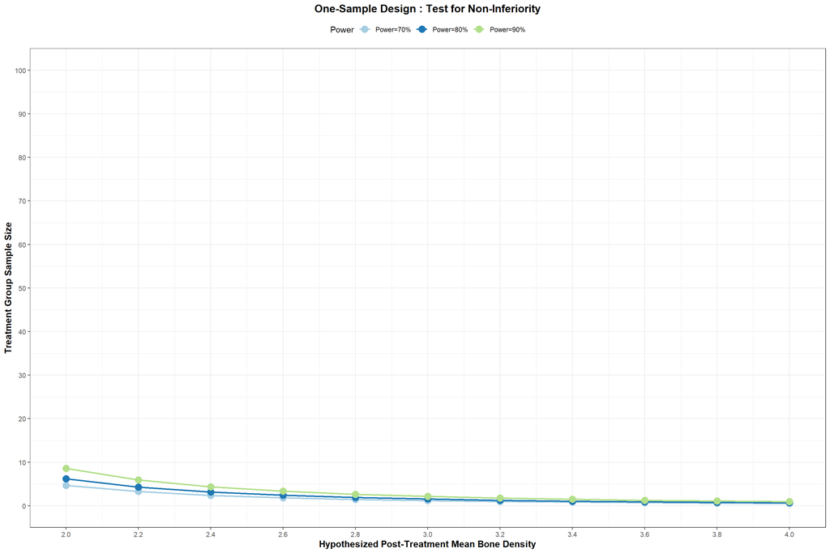

```r
##################################
# Plotting the sample sizes and power curves
##################################
(OneSampleDesign.NonInferiority.PowerAnalysis <-ggplot(OneSampleDesign.NonInferiority.Reshaped,
                                                      aes(x=Posttreatment.Mean.Bone.Density,
                                                          y=Sample.Size,
                                                          color=Power)) +
   geom_line(size=1)+
   geom_point(size=4)+
   theme_bw() +
   scale_color_brewer(palette="Paired") +
   scale_x_continuous(name="Hypothesized Post-Treatment Mean Bone Density",
                      limits=c(2,4),
                      breaks=seq(2,4,
                                 by=0.2)) +
  scale_y_continuous(name="Treatment Group Sample Size",
                     limits=c(0,100),
                     breaks=seq(0,100,by=10)) +
  theme(axis.title.x=element_text(color="black",face="bold",size=12),
        legend.position="top",
        axis.title.y=element_text(color="black",face="bold",size=12),
        plot.title=element_text(color="black",size=14,face="bold",hjust=0.50)) +
  ggtitle("One-Sample Design : Test for Non-Inferiority"))
```

### 1.1.3 Test for Superiority (OSD_SUPERIORITY)

**Code Chunk | Output**

```r
##################################
# Defining a range of possible hypothesized values for mu_Response
##################################
mu_Response=seq(2.0,4.0,0.2)

##################################
# Defining a fixed hypothesized value for mu_Reference
##################################
mu_Reference=1.5

##################################
# Defining a fixed hypothesized value for the standard deviation
##################################
sd=1

##################################
# Defining a fixed hypothesized value for the Type I error
##################################
alpha=0.05

##################################
# Defining a range of possible hypothesized values for the Type II error
##################################
beta=c(0.30,0.20,0.10)

##################################
# Defining the superiority delta
##################################
delta= 0.10

##################################
# Computing the range of samples sizes based on different levels of Type II errors
##################################
beta_1=beta[1]
(n_Beta30=(sd*(qnorm(1-alpha)+qnorm(1-beta_1))/(mu_Response-mu_Reference-delta))^2)
```

```
##  [1] 29.4103970 13.0712876  7.3525993  4.7056635  3.2678219  2.4008487
##  [7]  1.8381498  1.4523653  1.1764159  0.9722445  0.8169555
```

```r
ceiling(n_Beta30)
```

```
##  [1] 30 14  8  5  4  3  2  2  2  1  1
```

```r
z_Beta30=(mu_Response-mu_Reference-delta)/(sd/sqrt(n_Beta30))
(Power_Beta30=pnorm(z_Beta30-qnorm(1-alpha))+pnorm(-z_Beta30-qnorm(1-alpha)))
```

```
##  [1] 0.7000683 0.7000683 0.7000683 0.7000683 0.7000683 0.7000683 0.7000683
##  [8] 0.7000683 0.7000683 0.7000683 0.7000683
```

```r
beta_2=beta[2]
(n_Beta20=(sd*(qnorm(1-alpha)+qnorm(1-beta_2))/(mu_Response-mu_Reference-delta))^2)
```

```
##  [1] 38.640983 17.173770  9.660246  6.182557  4.293443  3.154366  2.415061
##  [8]  1.908197  1.545639  1.277388  1.073361
```

```r
ceiling(n_Beta20)
```

```
##  [1] 39 18 10  7  5  4  3  2  2  2  2
```

```r
z_Beta20=(mu_Response-mu_Reference-delta)/(sd/sqrt(n_Beta20))
(Power_Beta20=pnorm(z_Beta20-qnorm(1-alpha))+pnorm(-z_Beta20-qnorm(1-alpha)))
```

```
##  [1] 0.800018 0.800018 0.800018 0.800018 0.800018 0.800018 0.800018 0.800018
##  [9] 0.800018 0.800018 0.800018
```

```r
beta_3=beta[3]
(n_Beta10=(sd*(qnorm(1-alpha)+qnorm(1-beta_3))/(mu_Response-mu_Reference-delta))^2)
```

```
##  [1] 53.524046 23.788465 13.381011  8.563847  5.947116  4.369310  3.345253
##  [8]  2.643163  2.140962  1.769390  1.486779
```

```r
ceiling(n_Beta10)
```

```
##  [1] 54 24 14  9  6  5  4  3  3  2  2
```

```r
z_Beta10=(mu_Response-mu_Reference-delta)/(sd/sqrt(n_Beta10))
(Power_Beta10=pnorm(z_Beta10-qnorm(1-alpha))+pnorm(-z_Beta10-qnorm(1-alpha)))
```

```
##  [1] 0.9000024 0.9000024 0.9000024 0.9000024 0.9000024 0.9000024 0.9000024
##  [8] 0.9000024 0.9000024 0.9000024 0.9000024
```

```r
OneSampleDesign.Superiority <- as.data.frame(cbind(mu_Response,n_Beta30,n_Beta20,n_Beta10))
names(OneSampleDesign.Superiority) <- c("Posttreatment.Mean.Bone.Density",
                                 "Power=70%",
                                 "Power=80%",
                                 "Power=90%")

##################################
# Restructuring the data
##################################
OneSampleDesign.Superiority.Reshaped <- gather(OneSampleDesign.Superiority,
                                            "Power=70%","Power=80%","Power=90%",
                                            key="Power",
                                            value="Sample.Size")
OneSampleDesign.Superiority.Reshaped$Label <- rep("OSD_SUPERIORITY",nrow(OneSampleDesign.Superiority.Reshaped))

OneSampleDesign.Superiority.Reshaped
```

```
##    Posttreatment.Mean.Bone.Density     Power Sample.Size           Label
## 1                              2.0 Power=70%  29.4103970 OSD_SUPERIORITY
## 2                              2.2 Power=70%  13.0712876 OSD_SUPERIORITY
## 3                              2.4 Power=70%   7.3525993 OSD_SUPERIORITY
## 4                              2.6 Power=70%   4.7056635 OSD_SUPERIORITY
## 5                              2.8 Power=70%   3.2678219 OSD_SUPERIORITY
## 6                              3.0 Power=70%   2.4008487 OSD_SUPERIORITY
## 7                              3.2 Power=70%   1.8381498 OSD_SUPERIORITY
## 8                              3.4 Power=70%   1.4523653 OSD_SUPERIORITY
## 9                              3.6 Power=70%   1.1764159 OSD_SUPERIORITY
## 10                             3.8 Power=70%   0.9722445 OSD_SUPERIORITY
## 11                             4.0 Power=70%   0.8169555 OSD_SUPERIORITY
## 12                             2.0 Power=80%  38.6409827 OSD_SUPERIORITY
## 13                             2.2 Power=80%  17.1737701 OSD_SUPERIORITY
## 14                             2.4 Power=80%   9.6602457 OSD_SUPERIORITY
```

[output cut: 19 more lines]

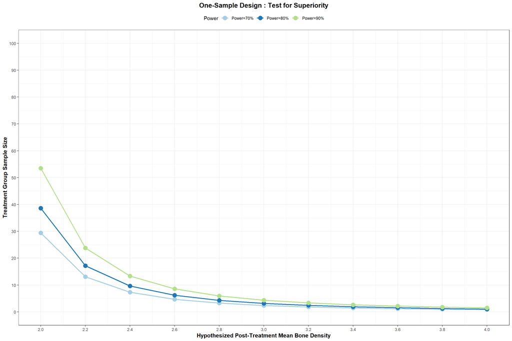

```r
##################################
# Plotting the sample sizes and power curves
##################################
(OneSampleDesign.Superiority.PowerAnalysis <- ggplot(OneSampleDesign.Superiority.Reshaped,
                                                      aes(x=Posttreatment.Mean.Bone.Density,
                                                          y=Sample.Size,
                                                          color=Power)) +
   geom_line(size=1)+
   geom_point(size=4)+
   theme_bw() +
   scale_color_brewer(palette="Paired") +
   scale_x_continuous(name="Hypothesized Post-Treatment Mean Bone Density",
                      limits=c(2,4),
                      breaks=seq(2,4,
                                 by=0.2)) +
  scale_y_continuous(name="Treatment Group Sample Size",
                     limits=c(0,100),
                     breaks=seq(0,100,by=10)) +
  theme(axis.title.x=element_text(color="black",face="bold",size=12),
        legend.position="top",
        axis.title.y=element_text(color="black",face="bold",size=12),
        plot.title=element_text(color="black",size=14,face="bold",hjust=0.50)) +
  ggtitle("One-Sample Design : Test for Superiority"))
```

### 1.1.4 Test for Equivalence (OSD_EQUIVALENCE)

**[Research Question]** Suppose that the mean bone density before the treatment is 1.5 SD. After treatment, the mean value is expected to range from 2.0 to 4.0 SD with increments of 0.2. For a special investigation, the study aims to demonstrate that the mean bone density post-treatment is not much worse or better than pre-treatment by a clinically meaningful difference equal to +0.10 SD. Given a level of significance of 0.05, evaluate the sample size range for a test of equivalence to achieve statistical test powers equal to 70%, 80% and 90%.  
**[Null Hypothesis]** Absolute value of (Post-treatment mean bone density - Pre-treatment mean bone density) >= Clinically meaningful difference  
**[Alternative Hypothesis]** Absolute value of (Post-treatment mean bone density - Pre-treatment) mean bone density < Clinically meaningful difference  
**[Hypothesis Test]** Rejection of the null hypothesis implies equivalence of the mean bone density treatment as compared to non-treatment, given the delta  
**[A]** Mean Response : 2.0 to 4.0 SD at 0.20 intervals  
**[B]** Reference : 1.5 SD  
**[C]** Standard Deviation : Not explicitly given but already factored into the mean values and will cancel out during computation  
**[D]** Alpha : 0.05  
**[E]** Beta : 0.30, 0.20 and 0.10 corresponding to 70%, 80% and 90% statistical powers  
**[F]** Delta : +0.10 SD testing margin for the Test of Equivalence hypothesis

**Code Chunk | Output**

```r
##################################
# Defining a range of possible hypothesized values for mu_Response
##################################
mu_Response=seq(2.0,4.0,0.2)

##################################
# Defining a fixed hypothesized value for mu_Reference
##################################
mu_Reference=1.5

##################################
# Defining a fixed hypothesized value for the standard deviation
##################################
sd=1

##################################
# Defining a fixed hypothesized value for the Type I error
##################################
alpha=0.05

##################################
# Defining a range of possible hypothesized values for the Type II error
##################################
beta=c(0.30,0.20,0.10)

##################################
# Defining the equivalence delta
##################################
delta= 0.10

##################################
# Computing the range of samples sizes based on different levels of Type II errors
##################################
beta_1=beta[1]
(n_Beta30=(sd*(qnorm(1-alpha)+qnorm(1-beta_1/2))/(delta-abs(mu_Response-mu_Reference)))^2)
```

```
##  [1] 44.933125 19.970278 11.233281  7.189300  4.992569  3.668010  2.808320
##  [8]  2.218920  1.797325  1.485393  1.248142
```

```r
ceiling(n_Beta30)
```

```
##  [1] 45 20 12  8  5  4  3  3  2  2  2
```

```r
z_Beta30=(abs(mu_Response-mu_Reference)-delta)/(sd/sqrt(n_Beta30))
(Power_Beta30=2*(pnorm(z_Beta30-qnorm(1-alpha))+pnorm(-z_Beta30-qnorm(1-alpha)))-1)
```

```
##  [1] 0.7000152 0.7000152 0.7000152 0.7000152 0.7000152 0.7000152 0.7000152
##  [8] 0.7000152 0.7000152 0.7000152 0.7000152
```

```r
beta_2=beta[2]
(n_Beta20=(sd*(qnorm(1-alpha)+qnorm(1-beta_2/2))/(delta-abs(mu_Response-mu_Reference)))^2)
```

```
##  [1] 53.524046 23.788465 13.381011  8.563847  5.947116  4.369310  3.345253
##  [8]  2.643163  2.140962  1.769390  1.486779
```

```r
ceiling(n_Beta20)
```

```
##  [1] 54 24 14  9  6  5  4  3  3  2  2
```

```r
z_Beta20=(abs(mu_Response-mu_Reference)-delta)/(sd/sqrt(n_Beta20))
(Power_Beta20=2*(pnorm(z_Beta20-qnorm(1-alpha))+pnorm(-z_Beta20-qnorm(1-alpha)))-1)
```

```
##  [1] 0.8000048 0.8000048 0.8000048 0.8000048 0.8000048 0.8000048 0.8000048
##  [8] 0.8000048 0.8000048 0.8000048 0.8000048
```

```r
(Power_Beta20=2*(pnorm(z_Beta20-qnorm(alpha)))-1)
```

```
##  [1] 0.9999952 0.9999952 0.9999952 0.9999952 0.9999952 0.9999952 0.9999952
##  [8] 0.9999952 0.9999952 0.9999952 0.9999952
```

```r
beta_3=beta[3]
(n_Beta10=(sd*(qnorm(1-alpha)+qnorm(1-beta_3/2))/(delta-abs(mu_Response-mu_Reference)))^2)
```

```
##  [1] 67.638586 30.061594 16.909647 10.822174  7.515398  5.521517  4.227412
##  [8]  3.340177  2.705543  2.235986  1.878850
```

```r
ceiling(n_Beta10)
```

```
##  [1] 68 31 17 11  8  6  5  4  3  3  2
```

```r
z_Beta10=(abs(mu_Response-mu_Reference)-delta)/(sd/sqrt(n_Beta10))
(Power_Beta10=2*(pnorm(z_Beta10-qnorm(1-alpha))+pnorm(-z_Beta10-qnorm(1-alpha)))-1)
```

```
##  [1] 0.9000008 0.9000008 0.9000008 0.9000008 0.9000008 0.9000008 0.9000008
##  [8] 0.9000008 0.9000008 0.9000008 0.9000008
```

```r
OneSampleDesign.Equivalence <- as.data.frame(cbind(mu_Response,n_Beta30,n_Beta20,n_Beta10))
names(OneSampleDesign.Equivalence) <- c("Posttreatment.Mean.Bone.Density",
                                 "Power=70%",
                                 "Power=80%",
                                 "Power=90%")

##################################
# Restructuring the data
##################################
OneSampleDesign.Equivalence.Reshaped <- gather(OneSampleDesign.Equivalence,
                                            "Power=70%","Power=80%","Power=90%",
                                            key="Power",
                                            value="Sample.Size")
OneSampleDesign.Equivalence.Reshaped$Label <- rep("OSD_EQUIVALENCE",nrow(OneSampleDesign.Equivalence.Reshaped))

OneSampleDesign.Equivalence.Reshaped
```

```
##    Posttreatment.Mean.Bone.Density     Power Sample.Size           Label
## 1                              2.0 Power=70%   44.933125 OSD_EQUIVALENCE
## 2                              2.2 Power=70%   19.970278 OSD_EQUIVALENCE
## 3                              2.4 Power=70%   11.233281 OSD_EQUIVALENCE
## 4                              2.6 Power=70%    7.189300 OSD_EQUIVALENCE
## 5                              2.8 Power=70%    4.992569 OSD_EQUIVALENCE
## 6                              3.0 Power=70%    3.668010 OSD_EQUIVALENCE
## 7                              3.2 Power=70%    2.808320 OSD_EQUIVALENCE
## 8                              3.4 Power=70%    2.218920 OSD_EQUIVALENCE
## 9                              3.6 Power=70%    1.797325 OSD_EQUIVALENCE
## 10                             3.8 Power=70%    1.485393 OSD_EQUIVALENCE
## 11                             4.0 Power=70%    1.248142 OSD_EQUIVALENCE
## 12                             2.0 Power=80%   53.524046 OSD_EQUIVALENCE
## 13                             2.2 Power=80%   23.788465 OSD_EQUIVALENCE
## 14                             2.4 Power=80%   13.381011 OSD_EQUIVALENCE
```

[output cut: 19 more lines]

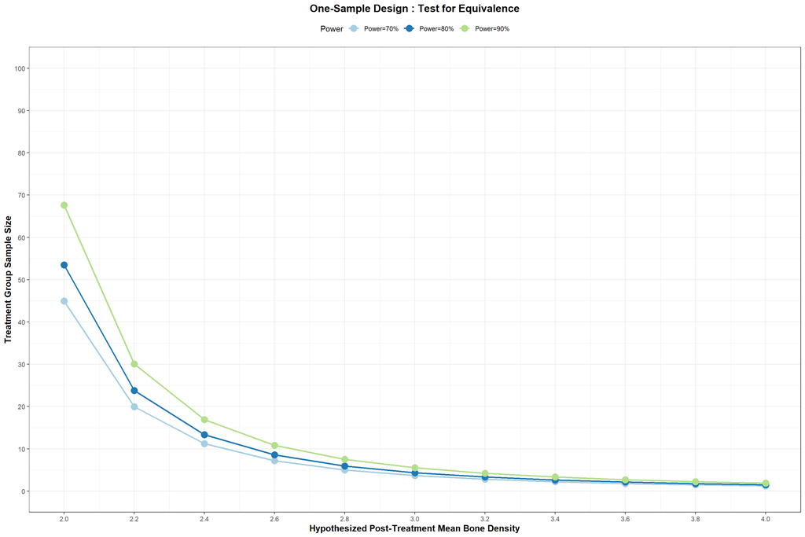

```r
##################################
# Plotting the sample sizes and power curves
##################################
(OneSampleDesign.Equivalence.PowerAnalysis <- ggplot(OneSampleDesign.Equivalence.Reshaped,
                                                      aes(x=Posttreatment.Mean.Bone.Density,
                                                          y=Sample.Size,
                                                          color=Power)) +
   geom_line(size=1)+
   geom_point(size=4)+
   theme_bw() +
   scale_color_brewer(palette="Paired") +
   scale_x_continuous(name="Hypothesized Post-Treatment Mean Bone Density",
                      limits=c(2,4),
                      breaks=seq(2,4,
                                 by=0.2)) +
  scale_y_continuous(name="Treatment Group Sample Size",
                     limits=c(0,100),
                     breaks=seq(0,100,by=10)) +
  theme(axis.title.x=element_text(color="black",face="bold",size=12),
        legend.position="top",
        axis.title.y=element_text(color="black",face="bold",size=12),
        plot.title=element_text(color="black",size=14,face="bold",hjust=0.50)) +
  ggtitle("One-Sample Design : Test for Equivalence"))
```

### 1.1.5 Consolidated Evaluation

**[A]** The minimum sample size required for the treatment group in a One-Sample Design study is dependent upon the following factors defined and hypothesized prior to the clinical research:  
**[A.1]** **Study Hypothesis** (Equality, Non-Inferiority, Superiority, Equivalence)  
**[A.2]** **Level of significance** (Alpha) : Lower value increases sample size  
**[A.3]** **Power of the test** (Beta) : Higher value increases sample size  
**[A.4]** **Data variability** (Standard Deviation) : Higher value increases sample size  
**[A.5]** **Epsilon** (Difference between Mean Response and Reference) : Lower value increases sample size  
**[A.6]** **Delta** (Testing margin, as applicable) : Higher value increases sample size  
**[B]** Given the level of significance = 5%, standard deviation = 1 and mean bone density values before treatment = 1.5 SD and after treatment = 2.0 to 4.0 SD representing epsilon values = 0.5 to 2.5, the range of sample sizes is given on the respective power analyses provided for each study hypotheses -  
**[B.1]** **OSD_EQUALITY** :  
**[B.1.1]** For 70% power, sample size = 1 to 25  
**[B.1.2]** For 80% power, sample size = 2 to 32  
**[B.1.3]** For 90% power, sample size = 2 to 43  
**[B.2]** **OSD_NONINFERIORITY** with Delta = -0.50 SD :  
**[B.2.1]** For 70% power, sample size = 1 to 5  
**[B.2.2]** For 80% power, sample size = 1 to 7  
**[B.2.3]** For 90% power, sample size = 1 to 9  
**[B.3]** **OSD_SUPERIORITY** with Delta = +0.10 SD :  
**[B.3.1]** For 70% power, sample size = 1 to 30  
**[B.3.2]** For 80% power, sample size = 2 to 39  
**[B.3.3]** For 90% power, sample size = 2 to 54  
**[B.4]** **OSD_EQUIVALENCE** with Delta = +0.10 SD:  
**[B.4.1]** For 70% power, sample size = 2 to 45  
**[B.4.2]** For 80% power, sample size = 2 to 54  
**[B.4.3]** For 90% power, sample size = 2 to 68

**Code Chunk | Output**

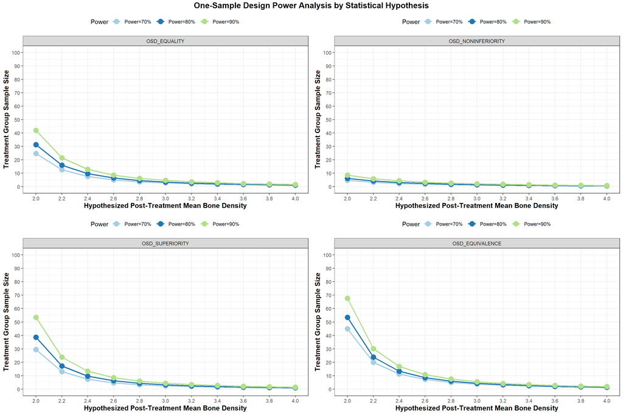

```r
##################################
# Consolidating the power analyses charts
##################################

OSD_EQUALITY.PowerAnalysis <- ggplot(OneSampleDesign.Equality.Reshaped,
                                     aes(x=Posttreatment.Mean.Bone.Density,
                                         y=Sample.Size,
                                         color=Power)) +
   geom_line(size=1)+
   geom_point(size=4)+
   theme_bw() +
   facet_grid(. ~ Label) +
   scale_color_brewer(palette="Paired") +
   scale_x_continuous(name="Hypothesized Post-Treatment Mean Bone Density",
                      limits=c(2,4),
                      breaks=seq(2,4,by=0.2)) +
  scale_y_continuous(name="Treatment Group Sample Size",
                     limits=c(0,100),
                     breaks=seq(0,100,by=10)) +
  theme(axis.title.x=element_text(color="black",face="bold",size=12),
        legend.position="top",
        axis.title.y=element_text(color="black",face="bold",size=12),
        plot.title=element_text(color="black",size=14,face="bold",hjust=0.50))

OSD_NONINFERIORITY.PowerAnalysis <- ggplot(OneSampleDesign.NonInferiority.Reshaped,
                                     aes(x=Posttreatment.Mean.Bone.Density,
                                         y=Sample.Size,
                                         color=Power)) +
   geom_line(size=1)+
   geom_point(size=4)+
   theme_bw() +
   facet_grid(. ~ Label) +
   scale_color_brewer(palette="Paired") +
   scale_x_continuous(name="Hypothesized Post-Treatment Mean Bone Density",
                      limits=c(2,4),
                      breaks=seq(2,4,by=0.2)) +
  scale_y_continuous(name="Treatment Group Sample Size",
                     limits=c(0,100),
                     breaks=seq(0,100,by=10)) +
  theme(axis.title.x=element_text(color="black",face="bold",size=12),
        legend.position="top",
        axis.title.y=element_text(color="black",face="bold",size=12),
        plot.title=element_text(color="black",size=14,face="bold",hjust=0.50))

OSD_SUPERIORITY.PowerAnalysis <- ggplot(OneSampleDesign.Superiority.Reshaped,
                                     aes(x=Posttreatment.Mean.Bone.Density,
                                         y=Sample.Size,
                                         color=Power)) +
   geom_line(size=1)+
   geom_point(size=4)+
   theme_bw() +
   facet_grid(. ~ Label) +
   scale_color_brewer(palette="Paired") +
   scale_x_continuous(name="Hypothesized Post-Treatment Mean Bone Density",
                      limits=c(2,4),
                      breaks=seq(2,4,by=0.2)) +
  scale_y_continuous(name="Treatment Group Sample Size",
                     limits=c(0,100),
                     breaks=seq(0,100,by=10)) +
  theme(axis.title.x=element_text(color="black",face="bold",size=12),
        legend.position="top",
        axis.title.y=element_text(color="black",face="bold",size=12),
        plot.title=element_text(color="black",size=14,face="bold",hjust=0.50))

OSD_EQUIVALENCE.PowerAnalysis <- ggplot(OneSampleDesign.Equivalence.Reshaped,
                                     aes(x=Posttreatment.Mean.Bone.Density,
                                         y=Sample.Size,
                                         color=Power)) +
   geom_line(size=1)+
   geom_point(size=4)+
   theme_bw() +
   facet_grid(. ~ Label) +
   scale_color_brewer(palette="Paired") +
   scale_x_continuous(name="Hypothesized Post-Treatment Mean Bone Density",
                      limits=c(2,4),
                      breaks=seq(2,4,by=0.2)) +
  scale_y_continuous(name="Treatment Group Sample Size",
                     limits=c(0,100),
                     breaks=seq(0,100,by=10)) +
  theme(axis.title.x=element_text(color="black",face="bold",size=12),
        legend.position="top",
        axis.title.y=element_text(color="black",face="bold",size=12),
        plot.title=element_text(color="black",size=14,face="bold",hjust=0.50))

OSD_PowerAnalysis <- ggarrange(OSD_EQUALITY.PowerAnalysis,
                               OSD_NONINFERIORITY.PowerAnalysis,
                               OSD_SUPERIORITY.PowerAnalysis,
                               OSD_EQUIVALENCE.PowerAnalysis,
                               ncol=2, nrow=2)

annotate_figure(OSD_PowerAnalysis,
                top = text_grob("One-Sample Design Power Analysis by Statistical Hypothesis",
                                color = "black",
                                face = "bold",
                                size = 14))
```

## 1.2 Two-Sample Design (TSD)

### 1.2.1 Test for Equality (TSD_EQUALITY)

**[Research Question]** Suppose that a difference of 6 to 12% in percent change of LDL is hypothesized between two cholesterol lowering agents. The study aims to demonstrate that the mean LDL percent change between the two cholesterol lowering agents are different. Given a level of significance of 0.05, standard deviation of 10% and matching ratio between both groups equal to 1, evaluate the sample size range for a test of equality to achieve statistical test powers equal to 70%, 80% and 90%.  
**[Null Hypothesis]** Lowering agent 1 mean LDL percent change - Lowering agent 2 mean LDL percent change equals 0  
**[Alternative Hypothesis]** Lowering agent 1 mean LDL percent change - Lowering agent 2 mean LDL percent does not equal 0  
**[Hypothesis Test]** Rejection of the null hypothesis implies difference between the mean LDL percent change between both lowering agents  
**[A]** Epsilon : 6 to 12% at 1% intervals  
**[B]** Standard Deviation : 10%  
**[C]** Alpha : 0.05  
**[D]** Beta : 0.30, 0.20 and 0.10 corresponding to 70%, 80% and 90% statistical powers  
**[E]** Kappa : 1.0  
**[F]** Delta : 0 testing margin for the Test of Equality hypothesis

**Code Chunk | Output**

```r
##################################
# Defining a range of possible hypothesized values for epsilon
##################################
epsilon=seq(6,12,1)

##################################
# Defining a fixed hypothesized value for the standard deviation
##################################
sd=10

##################################
# Defining a fixed hypothesized value for the Type I error
##################################
alpha=0.05

##################################
# Defining a range of possible hypothesized values for the Type II error
##################################
beta=c(0.30,0.20,0.10)

##################################
# Defining a fixed hypothesized value for kappa
##################################
kappa=1.0

##################################
# Computing the range of samples sizes based on different levels of Type II errors
##################################
beta_1=beta[1]
(n_Beta30=(1+1/kappa)*(sd*(qnorm(1-alpha/2)+qnorm(1-beta_1))/(epsilon))^2)
```

```
## [1] 34.289261 25.192110 19.287709 15.239671 12.344134 10.201764  8.572315
```

```r
ceiling(n_Beta30)
```

```
## [1] 35 26 20 16 13 11  9
```

```r
z_Beta30=(epsilon)/(sd*sqrt((1+1/kappa)/n_Beta30))
(Power_Beta30=pnorm(z_Beta30-qnorm(1-alpha/2))+pnorm(-z_Beta30-qnorm(1-alpha/2)))
```

```
## [1] 0.7000044 0.7000044 0.7000044 0.7000044 0.7000044 0.7000044 0.7000044
```

```r
beta_2=beta[2]
(n_Beta20=(1+1/kappa)*(sd*(qnorm(1-alpha/2)+qnorm(1-beta_2))/(epsilon))^2)
```

```
## [1] 43.60489 32.03624 24.52775 19.37995 15.69776 12.97335 10.90122
```

```r
ceiling(n_Beta20)
```

```
## [1] 44 33 25 20 16 13 11
```

```r
z_Beta20=(epsilon)/(sd*sqrt((1+1/kappa)/n_Beta20))
(Power_Beta20=pnorm(z_Beta20-qnorm(1-alpha/2))+pnorm(-z_Beta20-qnorm(1-alpha/2)))
```

```
## [1] 0.800001 0.800001 0.800001 0.800001 0.800001 0.800001 0.800001
```

```r
beta_3=beta[3]
(n_Beta10=(1+1/kappa)*(sd*(qnorm(1-alpha/2)+qnorm(1-beta_3))/(epsilon))^2)
```

```
## [1] 58.37457 42.88744 32.83570 25.94425 21.01485 17.36764 14.59364
```

```r
ceiling(n_Beta10)
```

```
## [1] 59 43 33 26 22 18 15
```

```r
z_Beta10=(epsilon)/(sd*sqrt((1+1/kappa)/n_Beta10))
(Power_Beta10=pnorm(z_Beta10-qnorm(1-alpha/2))+pnorm(-z_Beta10-qnorm(1-alpha/2)))
```

```
## [1] 0.9000001 0.9000001 0.9000001 0.9000001 0.9000001 0.9000001 0.9000001
```

```r
TwoSampleDesign.Equality <- as.data.frame(cbind(epsilon,n_Beta30,n_Beta20,n_Beta10))
names(TwoSampleDesign.Equality) <- c("Mean.LDL.Percent.Change",
                                 "Power=70%",
                                 "Power=80%",
                                 "Power=90%")

##################################
# Restructuring the data
##################################
TwoSampleDesign.Equality.Reshaped <- gather(TwoSampleDesign.Equality,
                                            "Power=70%","Power=80%","Power=90%",
                                            key="Power",
                                            value="Sample.Size")
TwoSampleDesign.Equality.Reshaped$Label <- rep("TSD_EQUALITY",nrow(TwoSampleDesign.Equality.Reshaped))

TwoSampleDesign.Equality.Reshaped
```

```
##    Mean.LDL.Percent.Change     Power Sample.Size        Label
## 1                        6 Power=70%   34.289261 TSD_EQUALITY
## 2                        7 Power=70%   25.192110 TSD_EQUALITY
## 3                        8 Power=70%   19.287709 TSD_EQUALITY
## 4                        9 Power=70%   15.239671 TSD_EQUALITY
## 5                       10 Power=70%   12.344134 TSD_EQUALITY
## 6                       11 Power=70%   10.201764 TSD_EQUALITY
## 7                       12 Power=70%    8.572315 TSD_EQUALITY
## 8                        6 Power=80%   43.604887 TSD_EQUALITY
## 9                        7 Power=80%   32.036244 TSD_EQUALITY
## 10                       8 Power=80%   24.527749 TSD_EQUALITY
## 11                       9 Power=80%   19.379950 TSD_EQUALITY
## 12                      10 Power=80%   15.697759 TSD_EQUALITY
## 13                      11 Power=80%   12.973355 TSD_EQUALITY
## 14                      12 Power=80%   10.901222 TSD_EQUALITY
## 15                       6 Power=90%   58.374573 TSD_EQUALITY
## 16                       7 Power=90%   42.887441 TSD_EQUALITY
## 17                       8 Power=90%   32.835697 TSD_EQUALITY
## 18                       9 Power=90%   25.944254 TSD_EQUALITY
## 19                      10 Power=90%   21.014846 TSD_EQUALITY
## 20                      11 Power=90%   17.367641 TSD_EQUALITY
## 21                      12 Power=90%   14.593643 TSD_EQUALITY
```

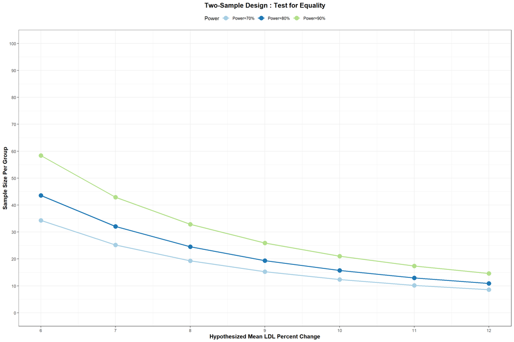

```r
##################################
# Plotting the sample sizes and power curves
##################################
(TwoSampleDesign.Equality.PowerAnalysis <- ggplot(TwoSampleDesign.Equality.Reshaped,
                                                      aes(x=Mean.LDL.Percent.Change,
                                                          y=Sample.Size,
                                                          color=Power)) +
   geom_line(size=1)+
   geom_point(size=4)+
   theme_bw() +
   scale_color_brewer(palette="Paired") +
   scale_x_continuous(name="Hypothesized Mean LDL Percent Change",
                      limits=c(6,12),
                      breaks=seq(6,12,by=1)) +
  scale_y_continuous(name="Sample Size Per Group",
                     limits=c(0,100),
                     breaks=seq(0,100,by=10)) +
  theme(axis.title.x=element_text(color="black",face="bold",size=12),
        legend.position="top",
        axis.title.y=element_text(color="black",face="bold",size=12),
        plot.title=element_text(color="black",size=14,face="bold",hjust=0.50)) +
  ggtitle("Two-Sample Design : Test for Equality"))
```

### 1.2.2 Test for Non-Inferiority (TSD_NONINFERIORITY)

**[Research Question]** Suppose that a difference of 6 to 12% in percent change of LDL is hypothesized between two cholesterol lowering agents. The study aims to demonstrate that the mean LDL percent change for the first cholesterol lowering agent is not much worse than the second cholesterol lowering agent by a clinically meaningful difference equal to −5. Given a level of significance of 0.05, standard deviation of 10% and matching ratio between both groups equal to 1, evaluate the sample size range for a test of non-inferiority to achieve statistical test powers equal to 70%, 80% and 90%.  
**[Null Hypothesis]** Lowering agent 1 mean LDL percent change - Lowering agent 2 mean LDL percent change <= Clinically meaningful difference  
**[Alternative Hypothesis]** Lowering agent 1 mean LDL percent change - Lowering agent 2 mean LDL percent > Clinically meaningful difference  
**[Hypothesis Test]** Rejection of the null hypothesis implies non-inferiority of the Lowering agent 1 mean LDL percent change as compared to Lowering agent 1, given the testing margin  
**[A]** Epsilon : 6 to 12% at 1% intervals  
**[B]** Standard Deviation : 10%  
**[C]** Alpha : 0.05  
**[D]** Beta : 0.30, 0.20 and 0.10 corresponding to 70%, 80% and 90% statistical powers  
**[E]** Kappa : 1.0  
**[F]** Delta : -5 testing margin for the Test of Non-Inferiority hypothesis

**Code Chunk | Output**

```r
##################################
# Defining a range of possible hypothesized values for epsilon
##################################
epsilon=seq(6,12,1)

##################################
# Defining a fixed hypothesized value for the standard deviation
##################################
sd=10

##################################
# Defining a fixed hypothesized value for the Type I error
##################################
alpha=0.05

##################################
# Defining a range of possible hypothesized values for the Type II error
##################################
beta=c(0.30,0.20,0.10)

##################################
# Defining a fixed hypothesized value for kappa
##################################
kappa=1.0

##################################
# Defining the non-inferiority delta
##################################
delta=-5

##################################
# Computing the range of samples sizes based on different levels of Type II errors
##################################
beta_1=beta[1]
(n_Beta30=(1+1/kappa)*(sd*(qnorm(1-alpha)+qnorm(1-beta_1))/(epsilon-delta))^2)
```

```
## [1] 7.777956 6.535644 5.568833 4.801697 4.182812 3.676300 3.256515
```

```r
ceiling(n_Beta30)
```

```
## [1] 8 7 6 5 5 4 4
```

```r
z_Beta30=(epsilon-delta)/(sd*sqrt((1+1/kappa)/n_Beta30))
(Power_Beta30=pnorm(z_Beta30-qnorm(1-alpha))+pnorm(-z_Beta30-qnorm(1-alpha)))
```

```
## [1] 0.7000683 0.7000683 0.7000683 0.7000683 0.7000683 0.7000683 0.7000683
```

```r
beta_2=beta[2]
(n_Beta20=(1+1/kappa)*(sd*(qnorm(1-alpha)+qnorm(1-beta_2))/(epsilon-delta))^2)
```

```
## [1] 10.219103  8.586885  7.316636  6.308732  5.495606  4.830123  4.278586
```

```r
ceiling(n_Beta20)
```

```
## [1] 11  9  8  7  6  5  5
```

```r
z_Beta20=(epsilon-delta)/(sd*sqrt((1+1/kappa)/n_Beta20))
(Power_Beta20=pnorm(z_Beta20-qnorm(1-alpha))+pnorm(-z_Beta20-qnorm(1-alpha)))
```

```
## [1] 0.800018 0.800018 0.800018 0.800018 0.800018 0.800018 0.800018
```

```r
beta_3=beta[3]
(n_Beta10=(1+1/kappa)*(sd*(qnorm(1-alpha)+qnorm(1-beta_3))/(epsilon-delta))^2)
```

```
## [1] 14.155120 11.894232 10.134731  8.738620  7.612309  6.690506  5.926538
```

```r
ceiling(n_Beta10)
```

```
## [1] 15 12 11  9  8  7  6
```

```r
z_Beta10=(epsilon-delta)/(sd*sqrt((1+1/kappa)/n_Beta10))
(Power_Beta10=pnorm(z_Beta10-qnorm(1-alpha))+pnorm(-z_Beta10-qnorm(1-alpha)))
```

```
## [1] 0.9000024 0.9000024 0.9000024 0.9000024 0.9000024 0.9000024 0.9000024
```

```r
TwoSampleDesign.NonInferiority <- as.data.frame(cbind(epsilon,n_Beta30,n_Beta20,n_Beta10))
names(TwoSampleDesign.NonInferiority) <- c("Mean.LDL.Percent.Change",
                                 "Power=70%",
                                 "Power=80%",
                                 "Power=90%")

##################################
# Restructuring the data
##################################
TwoSampleDesign.NonInferiority.Reshaped <- gather(TwoSampleDesign.NonInferiority,
                                            "Power=70%","Power=80%","Power=90%",
                                            key="Power",
                                            value="Sample.Size")
TwoSampleDesign.NonInferiority.Reshaped$Label <- rep("TSD_NONINFERIORITY",nrow(TwoSampleDesign.NonInferiority.Reshaped))

TwoSampleDesign.NonInferiority.Reshaped
```

```
##    Mean.LDL.Percent.Change     Power Sample.Size              Label
## 1                        6 Power=70%    7.777956 TSD_NONINFERIORITY
## 2                        7 Power=70%    6.535644 TSD_NONINFERIORITY
## 3                        8 Power=70%    5.568833 TSD_NONINFERIORITY
## 4                        9 Power=70%    4.801697 TSD_NONINFERIORITY
## 5                       10 Power=70%    4.182812 TSD_NONINFERIORITY
## 6                       11 Power=70%    3.676300 TSD_NONINFERIORITY
## 7                       12 Power=70%    3.256515 TSD_NONINFERIORITY
## 8                        6 Power=80%   10.219103 TSD_NONINFERIORITY
## 9                        7 Power=80%    8.586885 TSD_NONINFERIORITY
## 10                       8 Power=80%    7.316636 TSD_NONINFERIORITY
## 11                       9 Power=80%    6.308732 TSD_NONINFERIORITY
## 12                      10 Power=80%    5.495606 TSD_NONINFERIORITY
## 13                      11 Power=80%    4.830123 TSD_NONINFERIORITY
## 14                      12 Power=80%    4.278586 TSD_NONINFERIORITY
## 15                       6 Power=90%   14.155120 TSD_NONINFERIORITY
## 16                       7 Power=90%   11.894232 TSD_NONINFERIORITY
## 17                       8 Power=90%   10.134731 TSD_NONINFERIORITY
## 18                       9 Power=90%    8.738620 TSD_NONINFERIORITY
## 19                      10 Power=90%    7.612309 TSD_NONINFERIORITY
## 20                      11 Power=90%    6.690506 TSD_NONINFERIORITY
## 21                      12 Power=90%    5.926538 TSD_NONINFERIORITY
```

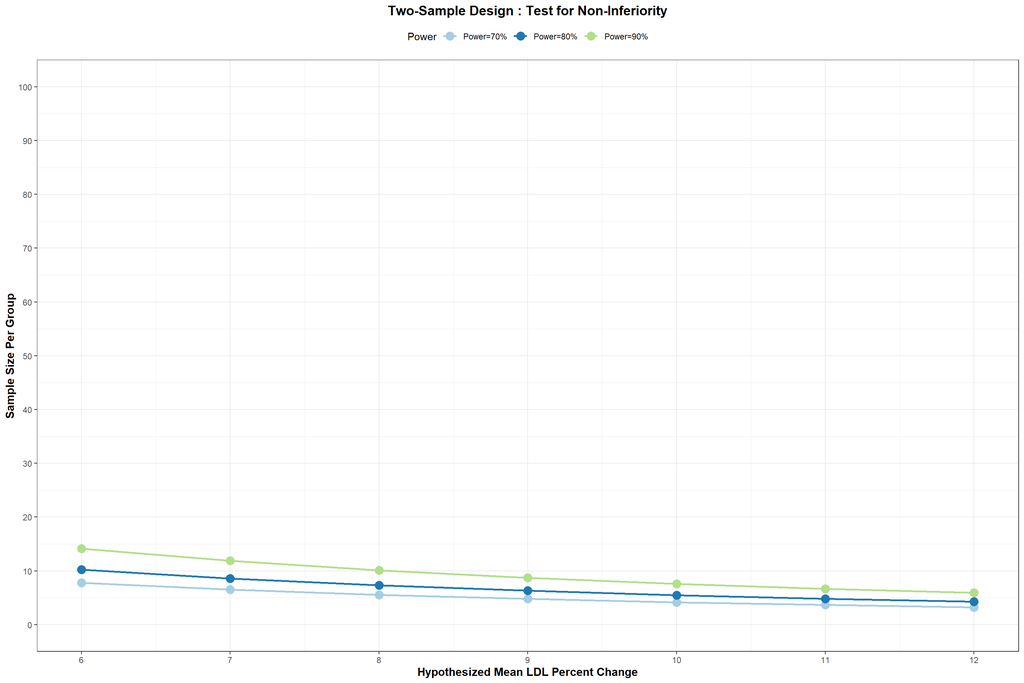

```r
##################################
# Plotting the sample sizes and power curves
##################################
(TwoSampleDesign.NonInferiority.PowerAnalysis <-ggplot(TwoSampleDesign.NonInferiority.Reshaped,
                                                      aes(x=Mean.LDL.Percent.Change,
                                                          y=Sample.Size,
                                                          color=Power)) +
   geom_line(size=1)+
   geom_point(size=4)+
   theme_bw() +
   scale_color_brewer(palette="Paired") +
   scale_x_continuous(name="Hypothesized Mean LDL Percent Change",
                      limits=c(6,12),
                      breaks=seq(6,12,by=1)) +
  scale_y_continuous(name="Sample Size Per Group",
                     limits=c(0,100),
                     breaks=seq(0,100,by=10)) +
  theme(axis.title.x=element_text(color="black",face="bold",size=12),
        legend.position="top",
        axis.title.y=element_text(color="black",face="bold",size=12),
        plot.title=element_text(color="black",size=14,face="bold",hjust=0.50)) +
  ggtitle("Two-Sample Design : Test for Non-Inferiority"))
```

### 1.2.3 Test for Superiority (TSD_SUPERIORITY)

**Code Chunk | Output**

```r
##################################
# Defining a range of possible hypothesized values for epsilon
##################################
epsilon=seq(6,12,1)

##################################
# Defining a fixed hypothesized value for the standard deviation
##################################
sd=10

##################################
# Defining a fixed hypothesized value for the Type I error
##################################
alpha=0.05

##################################
# Defining a range of possible hypothesized values for the Type II error
##################################
beta=c(0.30,0.20,0.10)

##################################
# Defining a fixed hypothesized value for kappa
##################################
kappa=1.0

##################################
# Defining the superiority delta
##################################
delta=1

##################################
# Computing the range of samples sizes based on different levels of Type II errors
##################################
beta_1=beta[1]
(n_Beta30=(1+1/kappa)*(sd*(qnorm(1-alpha)+qnorm(1-beta_1))/(epsilon-delta))^2)
```

```
## [1] 37.645308 26.142575 19.206790 14.705199 11.618922  9.411327  7.777956
```

```r
ceiling(n_Beta30)
```

```
## [1] 38 27 20 15 12 10  8
```

```r
z_Beta30=(epsilon-delta)/(sd*sqrt((1+1/kappa)/n_Beta30))
(Power_Beta30=pnorm(z_Beta30-qnorm(1-alpha))+pnorm(-z_Beta30-qnorm(1-alpha)))
```

```
## [1] 0.7000683 0.7000683 0.7000683 0.7000683 0.7000683 0.7000683 0.7000683
```

```r
beta_2=beta[2]
(n_Beta20=(1+1/kappa)*(sd*(qnorm(1-alpha)+qnorm(1-beta_2))/(epsilon-delta))^2)
```

```
## [1] 49.46046 34.34754 25.23493 19.32049 15.26557 12.36511 10.21910
```

```r
ceiling(n_Beta20)
```

```
## [1] 50 35 26 20 16 13 11
```

```r
z_Beta20=(epsilon-delta)/(sd*sqrt((1+1/kappa)/n_Beta20))
(Power_Beta20=pnorm(z_Beta20-qnorm(1-alpha))+pnorm(-z_Beta20-qnorm(1-alpha)))
```

```
## [1] 0.800018 0.800018 0.800018 0.800018 0.800018 0.800018 0.800018
```

```r
beta_3=beta[3]
(n_Beta10=(1+1/kappa)*(sd*(qnorm(1-alpha)+qnorm(1-beta_3))/(epsilon-delta))^2)
```

```
## [1] 68.51078 47.57693 34.95448 26.76202 21.14530 17.12769 14.15512
```

```r
ceiling(n_Beta10)
```

```
## [1] 69 48 35 27 22 18 15
```

```r
z_Beta10=(epsilon-delta)/(sd*sqrt((1+1/kappa)/n_Beta10))
(Power_Beta10=pnorm(z_Beta10-qnorm(1-alpha))+pnorm(-z_Beta10-qnorm(1-alpha)))
```

```
## [1] 0.9000024 0.9000024 0.9000024 0.9000024 0.9000024 0.9000024 0.9000024
```

```r
TwoSampleDesign.Superiority <- as.data.frame(cbind(epsilon,n_Beta30,n_Beta20,n_Beta10))
names(TwoSampleDesign.Superiority) <- c("Mean.LDL.Percent.Change",
                                 "Power=70%",
                                 "Power=80%",
                                 "Power=90%")

##################################
# Restructuring the data
##################################
TwoSampleDesign.Superiority.Reshaped <- gather(TwoSampleDesign.Superiority,
                                            "Power=70%","Power=80%","Power=90%",
                                            key="Power",
                                            value="Sample.Size")
TwoSampleDesign.Superiority.Reshaped$Label <- rep("TSD_SUPERIORITY",nrow(TwoSampleDesign.Superiority.Reshaped))

TwoSampleDesign.Superiority.Reshaped
```

```
##    Mean.LDL.Percent.Change     Power Sample.Size           Label
## 1                        6 Power=70%   37.645308 TSD_SUPERIORITY
## 2                        7 Power=70%   26.142575 TSD_SUPERIORITY
## 3                        8 Power=70%   19.206790 TSD_SUPERIORITY
## 4                        9 Power=70%   14.705199 TSD_SUPERIORITY
## 5                       10 Power=70%   11.618922 TSD_SUPERIORITY
## 6                       11 Power=70%    9.411327 TSD_SUPERIORITY
## 7                       12 Power=70%    7.777956 TSD_SUPERIORITY
## 8                        6 Power=80%   49.460458 TSD_SUPERIORITY
## 9                        7 Power=80%   34.347540 TSD_SUPERIORITY
## 10                       8 Power=80%   25.234927 TSD_SUPERIORITY
## 11                       9 Power=80%   19.320491 TSD_SUPERIORITY
## 12                      10 Power=80%   15.265573 TSD_SUPERIORITY
## 13                      11 Power=80%   12.365114 TSD_SUPERIORITY
## 14                      12 Power=80%   10.219103 TSD_SUPERIORITY
## 15                       6 Power=90%   68.510779 TSD_SUPERIORITY
## 16                       7 Power=90%   47.576930 TSD_SUPERIORITY
## 17                       8 Power=90%   34.954479 TSD_SUPERIORITY
## 18                       9 Power=90%   26.762023 TSD_SUPERIORITY
## 19                      10 Power=90%   21.145302 TSD_SUPERIORITY
## 20                      11 Power=90%   17.127695 TSD_SUPERIORITY
## 21                      12 Power=90%   14.155120 TSD_SUPERIORITY
```

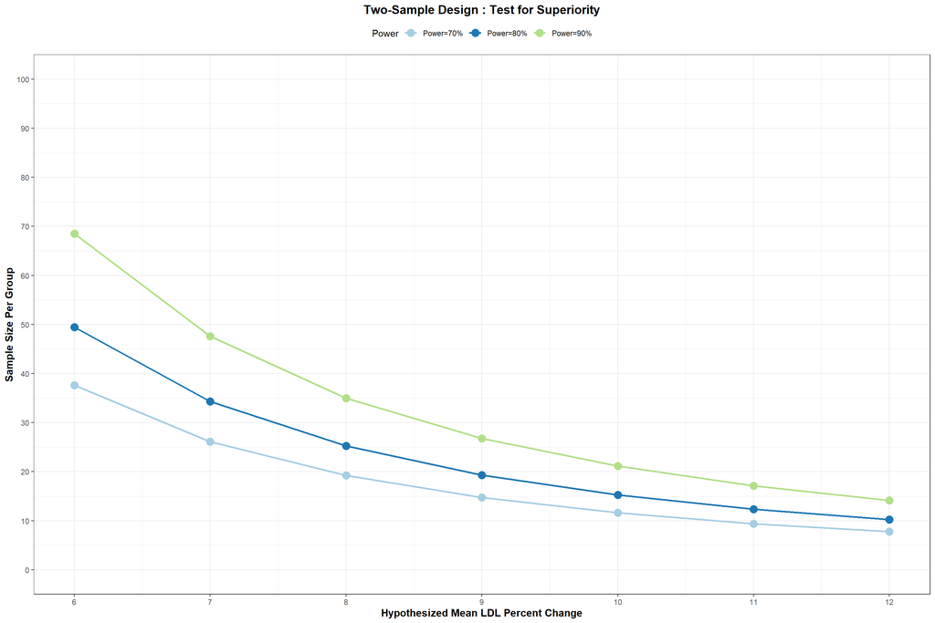

```r
##################################
# Plotting the sample sizes and power curves
##################################
(TwoSampleDesign.Superiority.PowerAnalysis <-ggplot(TwoSampleDesign.Superiority.Reshaped,
                                                      aes(x=Mean.LDL.Percent.Change,
                                                          y=Sample.Size,
                                                          color=Power)) +
   geom_line(size=1)+
   geom_point(size=4)+
   theme_bw() +
   scale_color_brewer(palette="Paired") +
   scale_x_continuous(name="Hypothesized Mean LDL Percent Change",
                      limits=c(6,12),
                      breaks=seq(6,12,by=1)) +
  scale_y_continuous(name="Sample Size Per Group",
                     limits=c(0,100),
                     breaks=seq(0,100,by=10)) +
  theme(axis.title.x=element_text(color="black",face="bold",size=12),
        legend.position="top",
        axis.title.y=element_text(color="black",face="bold",size=12),
        plot.title=element_text(color="black",size=14,face="bold",hjust=0.50)) +
  ggtitle("Two-Sample Design : Test for Superiority"))
```